# Having Confidence in the Binomial Likelihood

Bob O’Hara

# The Problem (from last week)

First, if you dare [you can watch this video](https://ntnu.cloud.panopto.eu/Panopto/Pages/Viewer.aspx?id=79a5b98a-ddf4-4752-b3b8-ae28009ec22c):

[interactive chart not shown]

We have a globe. We have sampled 13 points (by spinning the globe around): 6 of these were land and 7 were sea. We want to know what proportion of the globe is land. We call each data point a “trial”.

Because of the way we sampled, we can assume that the probability of each point being Land is constant, and these are independent of each other. From this, we can assume that if we did the same experiment many times, the outcomes would follow a binomial distribution. Figure 1 shows a binomial distribution, i.e. the possible outcomes if we had 13 trials, and the probability of land was 0.4.

$$Pr(n = r | N, p) = \frac{N !}{r! (N-r)!} p^r (1-p)^{N-r}$$

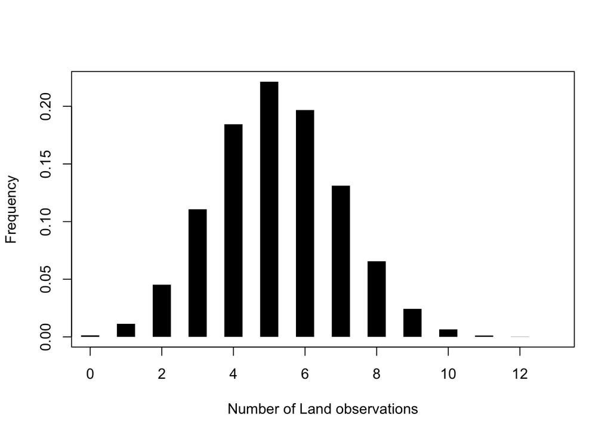

Fig. 1: A binomial probability

```r
PrLand <- 0.4
nTrials <- 13
n <- 0:nTrials
Pr <- dbinom(n, nTrials, PrLand)

plot(n, Pr, type="h", lwd=20, lend=3,
     xlab="Number of Land observations", ylab="Frequency")
```

Fig. 1 is a plot of the probabilities of different outcomes if $p=0.4$. But in reality we do not know what $p$ is: this is what we want to estimate. If we have some data (e.g. $n=6$), we can draw a curve that shows the probability as a function of $p$. We have drawn one in Fig. 2. From this we can see that we are more likely to get the data if the probability is close to 0.5, and that values from around 0.3 and 0.6 are also reasonable. But we want to be more precise about this, so we want to (a) find the value that is most likely to give the data, and (b) find some measure of spread around that which suggests what values are likely.

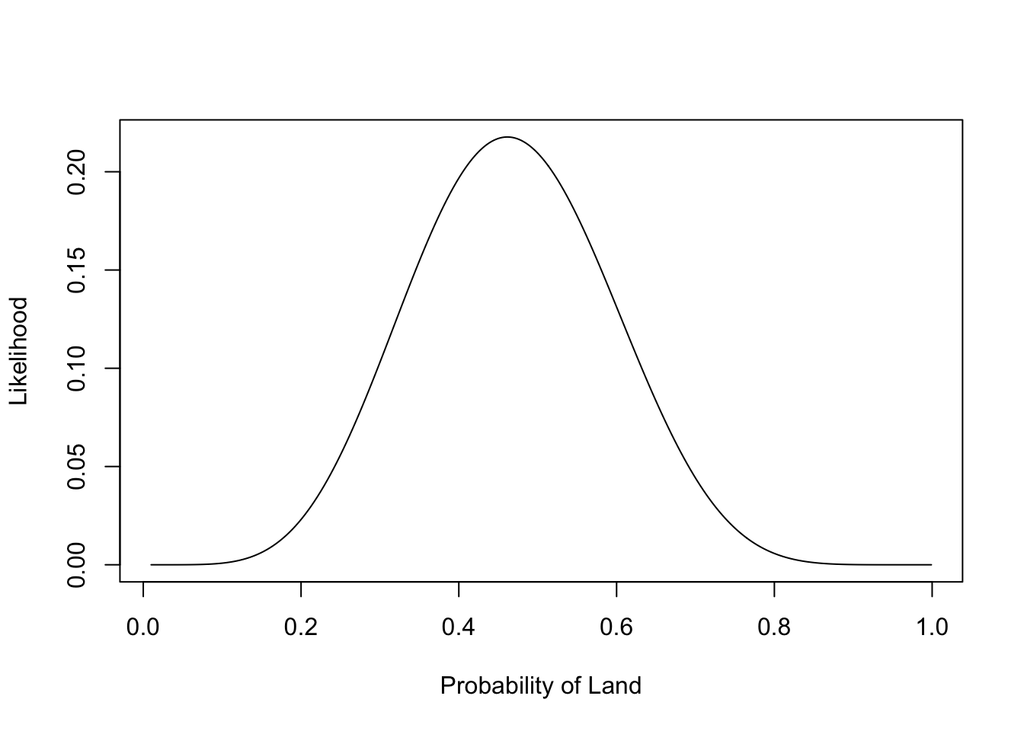

Fig. 2: A binomial likelihood

```r
nLand <- 6
p <- seq(0.01, 0.999, length=500)
Pr <- dbinom(nLand, nTrials, p)

plot(p, Pr, type="l",
     xlab="Probability of Land", ylab="Likelihood")
```

## Finding the MLE

The probability, $Pr(n = r | N, p)$, is a mathematical description of how the data came about: it is a statistical model. We assume that there is some unknown “true” value of the parameter, and this is what we are trying to estimate. Thus the parameter is fixed, and the data are what varies. We thus want to find the parameter which is most likely to give rise to the data.

We can vary $p$, and calculate $Pr(n = r | N, p)$, so that $Pr(n = r | N, p)$ is a function of $p$. When the probability of the data is a function of the parameters, we call this the likelihood. Our aim is to find the best estimate of $p$, i.e. the one which has the highest likelihood of giving the data. We thus want to maximise the likelihood: the estimate we get is called the *maximum likelihood estimator*, which is often abbreviated to m.l.e., or MLE. There are several ways to find the mle. Here we will find an analytic solution, i.e. use pencil and paper, to calculate the expression for the m.l.e.

## Maximising the likelihood: the maths

The maximum of the likelihood is at the same value of $p$ as the maximum of the log-likelihood, and it is easier to woth on the log scale. So we will work with $\log(L(p|N, r)) = l(p|N, r)$

$$l(p | n) = \log(N !) - \log(r!) - \log((N-r)!) + r \log(p) + (N-r)
\log(1-p)$$

Becuse this is a function of $p$, not $N$ or $r$, several terms are constants:

$$l(p | n) = r \log(p) + (N-r) \log(1-p) + C$$

We differentiate with this respect to p to get

$$\frac{d l(p | n)}{dp} = \frac{r}{p} - \frac{N-r}{1-p}$$

Then we set the gradient to 0, $0 = \frac{r}{p} - \frac{N-r}{1-p}$, and rearrange to end up with

$$\hat{p} = \frac{r}{N}$$

### Likelihood vs Probability

In everyday life, we often use likelihood and probability to mean the same thing. But in statistics they mean slightly different things.

First, **probability**. This you should know: if something has a higher probability, it is more likely to happen. To be more precise, if you try to do something a lot of times, the probability is the proportion of times you expect is to happen. e.g. if the probability of Scunthorpe United scoring between 44 and 73 goals in a season is 0.3, then over lots of seasons we would expect to see it happening about 30% of the time. So probabilities are statements about events, which may or may not happen, and how likely they are to happen. We will leave it as that, without delving into technical definitions.

Now, **likelihood**. First, you can think of it as a specific type of probability. It is (almost: see below) the probability of seeing the data you have collected, given the parameters of a model and the model. So, we might think that the number of goals Scunthorpe United score in a season should follow a Poisson distribution. In 2024/5 they scored 76 goals. We can think about how likely that is. If we think on average they score 70 goals a season, then the likelihood is the probability of scoring 76 given an average of 70, and that the number of goals follows a Poisson distribution. We can actually calculate this as `dpois(76, lambda=70)` which gives 0.0356. But we can also calculate the likelihood of 76 goials if the mean was actually 73.6: `dpois(76, lambda=73.6)` which gives 0.044, which is higher.

Why is likelihood not quite a probability (and why doesn’t it matter)? Because we can also calculate likelihoods for continuous distributions, like height or the time it takes for me to write a sentence. For continuous distributions, we have to talk about the probability of events being between two values, e.g. the probability it would take between 3 and 24 seconds for me to write a sentence. Our model for a continuous distribution is written as a *probability density*: a higher density is like a higher probability. We can still calculate a density, and a likelihood for a continuous distribution is just the probability density for the observation (e.g. me taking 4.63 seconds to write a sentence) given whatever parameter we have for our model. The bottom line is that we can think about discrete events adn continuous probabilities in the same way (and years ago a Russian mathematician proved this works).

## This Week: Uncertainty in the Estimate

Because different samples give different estimates, we want to quantify this, to suggest plausible values. First, let’s set up the data (from last week), the likelihood and the MLE:

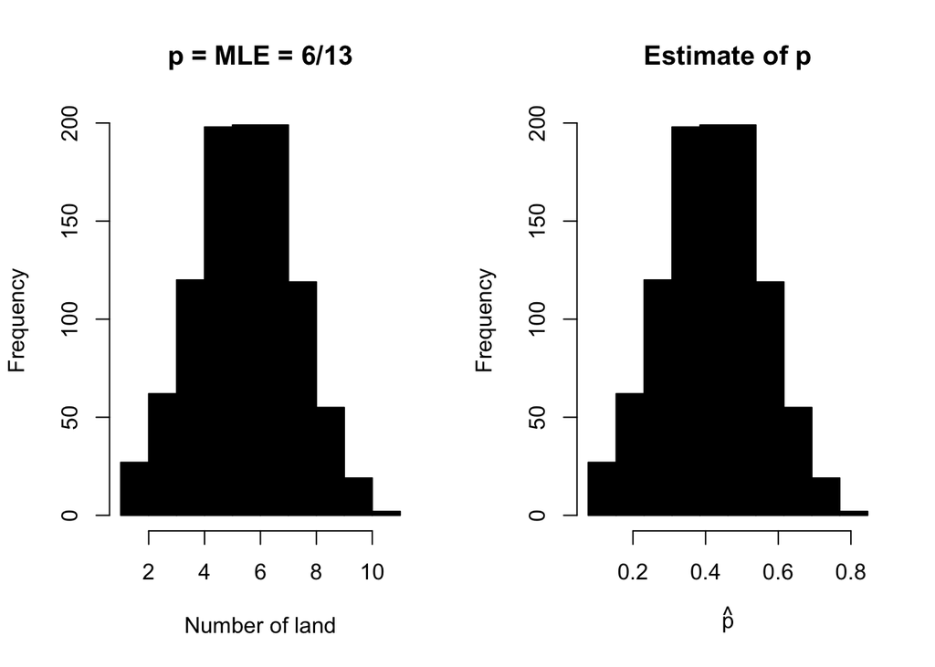

```r
# Source the script directly from the internet
source('https://www.math.ntnu.no/emner/ST2304/2025v/Module03/InferenceFunctions.R')
# source('InferenceFunctions.R') # source locally
nTrials <- 13
nLand <- 6

phat <- mleGlobe(NLand = nLand, NTrials = nTrials)  # The MLE

SimsMLE <- simGlobe(6/13, 13, 1000)["Land",] # simulate data from MLE
Sims6 <- simGlobe(0.6, 13, 1000)["Land",] # simulate data from different estiamte of p

# Plot simulated data, and distribution of estimates of p
par(mfrow=c(1,2)) # set up the plotting window to have 2 panels
# Plot 1 - the distribution of simulated datasets when p = 6/13
h.mle <- hist(SimsMLE, xlab = "Number of land", main = "p = MLE = 6/13", col=1)
# Plot 2 - the distribution of MLE from each of the simulated datasets
hist(mleGlobe(SimsMLE, 13), xlab = expression(hat(p)), breaks=h.mle$breaks/13,
      col=1, main ="Estimate of p")
```

We have plotted the likelihood, but we don’t really want to summarise the distibution with a plot: it is easier to use statistical summaries of the distribution. So what statistical summaries could we use?

## Confidence Intervals

If you prefer the spoken word, [you can watch this video introducing the ideas behind confidence intervals](https://ntnu.cloud.panopto.eu/Panopto/Pages/Viewer.aspx?id=c5a7005c-b676-45e2-a783-ae2800a4faa6):

[interactive chart not shown]

Confidence intervals give the range of values of the statistic that are likely. Usually we use 95%.

```
A 95% confidence interval is an interval that contains the true value in 95% of repeated samples
```

This is not the easiest definition to understand! We would like to be able to say that a 95% confidence interval has a 95% probability of containing the true value. But unfortunately we cannot say this, because we are assuming the parameter is fixed, and once we have calculated the interval, that is fixed too. So either the interval contains the true value or it does not.

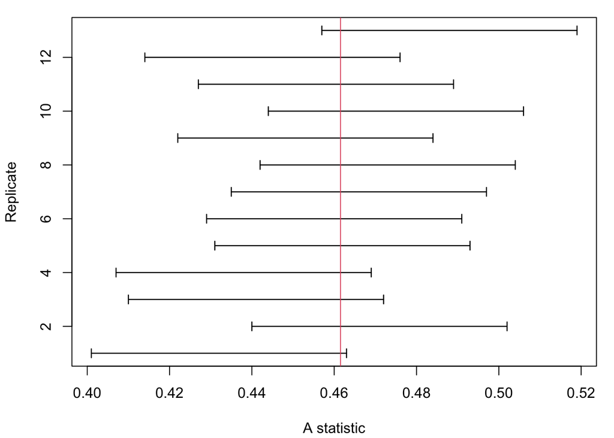

Figure: Some confidence intervals, from repeated sampling

But what we can say is that if we took the same sort of sample many times, then 95% of those intervals would contain the true value. The thinking here is that the data are random, and could (in principle, if not practice) be sampled repeatedly. So we are thinking about uncertainty in differnet realisations of the data. By simulating the data many times you are simulating the philosophical idea of repeated samples.

## Constructing a Confidence interval

For continuous data this is straightforward: we exclude the top and bottom 2.5% of the distribution of the statistic.

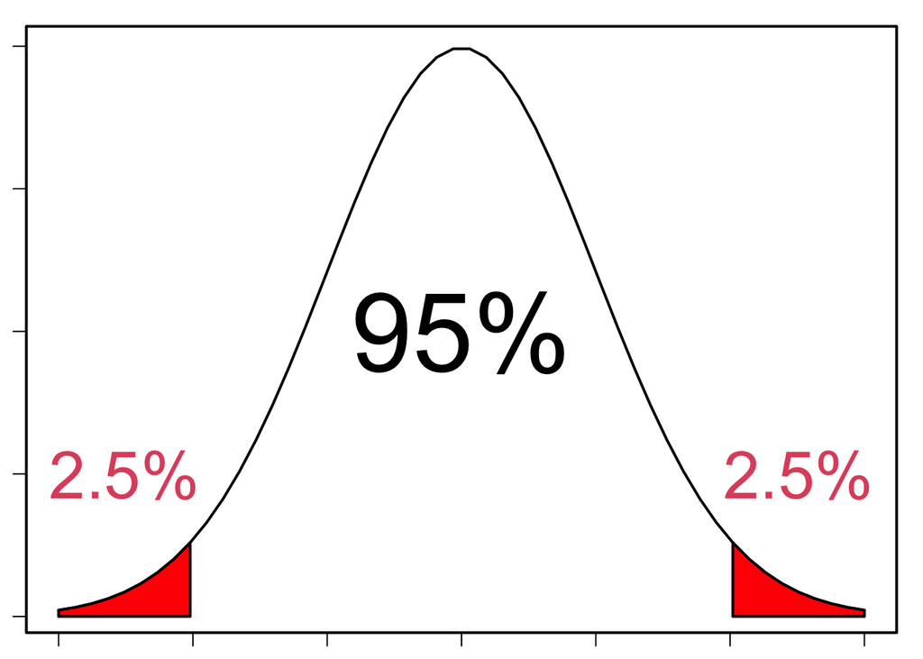

The confidence interval is the white area in the plot above, nad we only need to give the bounds on the interval, e.g. we could have an interval of (-4,7).

```r
nLandBig <- 600
nTrialsBig <- 1300
pHatBig <- nLandBig/nTrialsBig
```

The maximum likelihood estimate is 0.46. But what about the confidence interval? Above I explained

```
[I]f the estimate is correct, then if we randomly sampled the data many times, we would get a distribution of the estimates. We can summarise this distribution by specifying the interval with would contain the estimates 95% of the time.
```

So, let’s simulate:

For the data estimated above (i.e. with 1300 trials, 600 Land, so p = 0.4615), use `simGlobe()` to simulate the data you would expect if the MLE was true (see last week’s work, or the use of `simGlobe()` above). Do 1000 simulations, and plot the distribution of estimates on a histogram

**I forgot how to make a histogram**

Use the function `hist()`.

**I had a go, now show me the answer:**

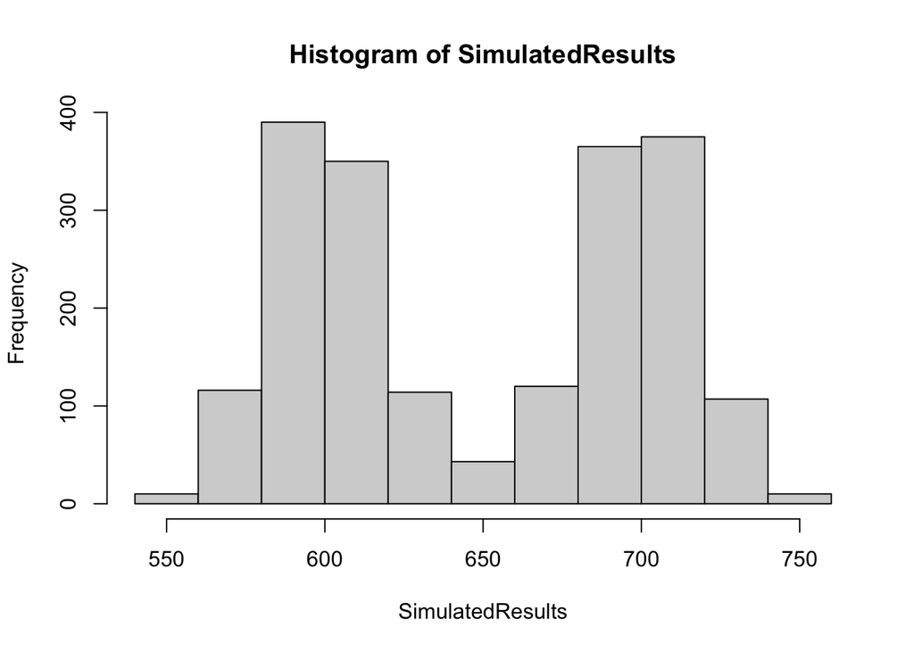

```r
SimulatedResults <- simGlobe(NTrials = 1300,
                             nSims = 1000,
                             probability = 0.4615)

hist(SimulatedResults)
```

**Oh no! I got two peaks, that doesn’t look right.**

What has happened is I have plotted both Land and Sea results. I only want Land. To get just Land I can use the code `["Land", ]`. The `[]` brackets are used to reference points INSIDE an object. They do this by `x[row,column]` if `x` is an object. So, `["Land", ]` takes the row called Land from an object and ALL columns.

Let’s try that.

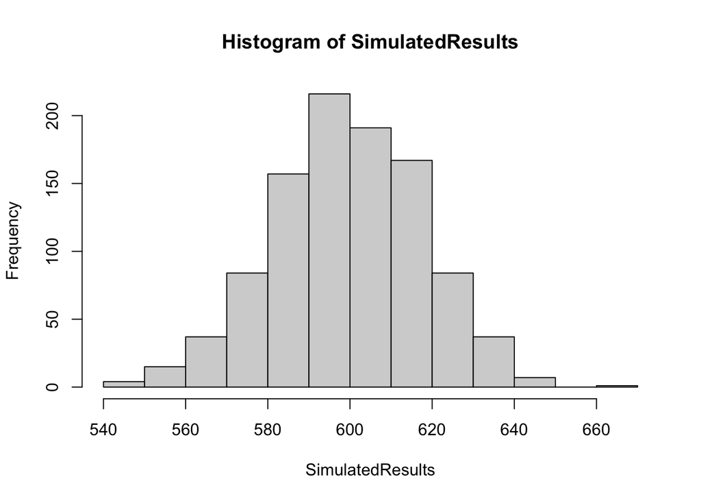

```r
SimulatedResults <- simGlobe(NTrials = 1300,
                             nSims = 1000,
                             probability = 0.4615)["Land",]

hist(SimulatedResults)
```

**Yay, that looks better.**

## Confidence Intervals and Quantiles

There are a few ways to calculate confidence intervals. One way is to sort the numbers from lowest to highest

```r
# simulate data (you should do this using the MLE)
SimDist1k <- simGlobe(probability=pHatBig, NTrials=nTrialsBig, nSims = 1e3)["Land",]
# For each simulation, calculate the MLE for that simulated data
SimMLE1k <- mleGlobe(SimDist1k, 1000)
# and sort...
sort(SimMLE1k)[1:10]
```

```
##  [1] 0.544 0.550 0.550 0.550 0.553 0.553 0.554 0.555 0.555 0.558
```

and then take the values that are 2.5% of the way from the bottom, and 2.5% of the way from the top:

```r
sort(SimMLE1k)[c(0.025*length(SimMLE1k),
                  0.975*length(SimMLE1k))]
```

```
## [1] 0.565 0.638
```

The values 2.5% of the way from the bottom, and 2.5% of the way from the top are called **quantiles**. A x% quantile is a value of a distribution with x% of the distribution less than it

- a median is the 50% quantile
- the 25% and 75% quantiles are called quartiles (in addition to the median, they split the data into 4 quarters)

So, we can just need the 2.5% and 97.5% quantiles. There is a function in R to do this:

```r
quantile(SimMLE1k, c(0.025, 0.975))
```

```
##  2.5% 97.5%
## 0.565 0.638
```

For the data above (600 Lands, 1300 trials), calculate the confidence interval, by simulating data with the MLE, and calculating the quantiles (with the `quantile()` function).

**I had a go, now show me the answer:**

For this, we can actually use our previous simulations from the part above. This is because we used the MLE to simulate those. I called mine `SimulatedResults`.

```r
# a reminder of the code from above
SimulatedResults <- simGlobe(NTrials = 1300,
                             nSims = 1000,
                             probability = 0.4615)["Land",]

# For each simulation, calculate the MLE for that simulated data
SimMLE <- mleGlobe(NLand = SimulatedResults,
                   NTrials = 1300)

# and find the quantiles
quantile(SimMLE, c(0.025, 0.975))
```

```
##      2.5%     97.5%
## 0.4353846 0.4884615
```

These results will be slightly different for each person as there is a random element. But it should be close to 0.43 and 0.48.

*HINT: it is very useful to always write the argument names in a function call e.g. NLand = …, otherwise it can be easy to forgot which arguments are used in each function.*

In words this code:

- uses a function to simulate repeat samples of data (mimicking going out and repeating a field survey or a lab experiment) based on a MLE from one dataset.
- uses a function to find the MLE of each of these simulated repeat datasets. Just like the first one.
- uses the `quantile()` function to find the middle 95% of the MLE results. It takes off the lowest 2.5% of estimates and the highest 2.5% of estimates. This represents a 95% confidence interval.

With simulation there is simulation error: different simulations will give slightly different results, because thesimulations are random. But we know that our data follows a binomial distribution, so we can calculate the probabilities exactly (this would be like having infinite simulations). R, naturally, has a function to do this. Before getting to that function, it is worth remembering the `dbinom()` function:

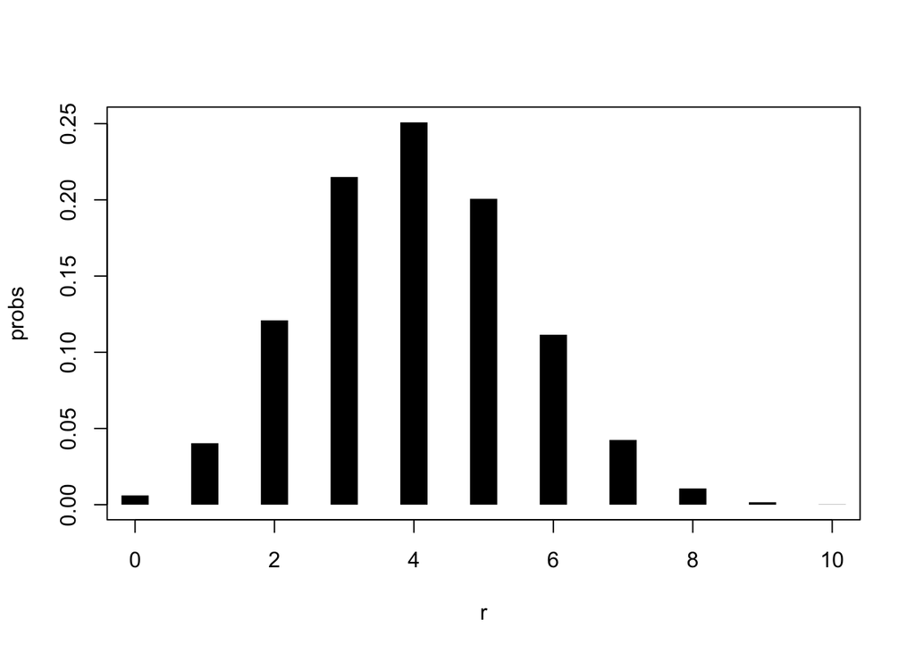

```r
r <- 0:10
probs <- dbinom(r, 10, 0.4)
plot(r, probs, type="h", lwd=20, lend=3)
```

This calculates the probability of getting an observation, $r$, given the parameters of the distribution (i.e. $N$ and $p$). But there is also a function called `qbinom()`, which calculates the quantiles, i.e. the value of `r` for which $Pr(n \leq r)=p$ (e.g. `qbinom(c(0.025, 0.975), 10, 0.4)`). So we can calculate our confidence intervals with this: use the 2.5% and 97.5% quantiles and the number of trials as the size, and the MLE for the propotion of land as prob:

`qbinom(p=c(0.025, 0.975), size=??, prob=??)/??`

For the data estimated above, usq `qbinom()` to calculate the confidence interval. You need to divide by the size, because qbinom() calculates the quantiles for r, and the estimate is r/N. How close is it to the ones you got by simulation?

**I had a go, now show me the answer:**

```r
qbinom(p=c(0.025, 0.975), size=1300, prob=0.4615)/1300
```

```
## [1] 0.4346154 0.4884615
```

These results are a pretty much the same as those we got from `quantile()`, if yours are different, you probably are inputting BOTH Land and Sea to the function. You need to make sure you use the `["Land",]` code when creating your simulations object.

## What, exactly, is a confidence interval?

Remember, our parameters are fixed, and our data are random. So any statistics we calculate from the data are also random. This means that our confidence interval has to say something about the data (and statistics), not the parameter: the estimator, not the estimand.

A confidence interval is thus an interval that will contain a population parameter (i.e. the true value) a specified proportion of the time. We can look at this by simulating lots of data, calculating the confidence interval for each one, and seeing how many contain the true value:

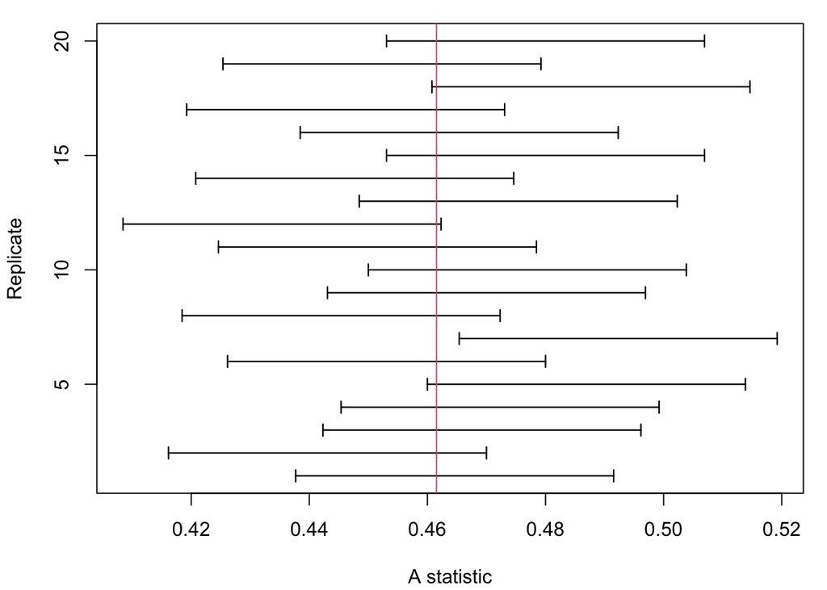

```r
ConfIntervals <- CIGlobe(NLand=SimDist1k[1:20], NTrials=nTrialsBig)

rep <- 1:nrow(ConfIntervals)

par(mar=c(4.1,4.1,1,1))
plot(1,1, type="n", xlim=range(ConfIntervals), ylim=range(rep), xlab="A statistic", ylab="Replicate")
arrows(x0=ConfIntervals[,"Lower"], y0=rep, x1=ConfIntervals[,"Upper"], y1=rep, lwd=1.2, angle = 90, code=3, length=0.05)
abline(v=pHatBig, col=2)
```

```r
# Calculate proportion of CIs containing true value
IsInCI <- function(CIs, True) {
# Check if Lower < True < Upper
  InCI <- CIs[,"Lower"] < True & CIs[,"Upper"] > True
# Return proportion where InCI is TRUEmistakes
  mean(InCI)
}

IsInCI(ConfIntervals, True = phat)
```

```
## [1] 0.95
```

i.e. if we repeatedly sample the same population, 95% of confidence intervals will include the “true” parameter.

For the estimate of $p$ calcluated above (i.e. from 600 Lands and 700 Seas), simulate the data, calculate the confidence intervals for the data and then estimate the proportion of confidence intervals containing the “true”” value.

**I had a go, now show me the answer:**

Again, we can use the `SimulatedResults` from the previous sections.

```r
ConfIntervals <- CIGlobe(NLand=SimulatedResults,
                         NTrials=1300)

# Make sure to run the function:

# Calculate proportion of CIs containing true value
IsInCI <- function(CIs, True) {
# Check if Lower < True < Upper
  InCI <- CIs[,"Lower"] < True & CIs[,"Upper"] > True
# Return proportion where InCI is TRUEmistakes
  mean(InCI)
}

IsInCI(ConfIntervals, True = phat)
```

```
## [1] 0.95
```

## Confidence Interval for a Binomial with different Ns

If the data are discrete then the estimate is discrete, e.g. if we have 4 trials the only possible estiamtes are 0, 0.25, 0.5, 0.75 and 1.0. We can’t guarantee that we will get exaclty 95% of the distribution.

Because the data are discrete, we have a smaller number of possible values of the confidence interval: if we have 5 trials (say), the estimates of p can only be 0, 0.2, 0.4, 0.6, 0.8 and 1. So the limits of the confidence interval can only be these values too:

```r
N.small <- 5
p.small <- 3/5 # if we observe 3 successes

qbinom(p=c(0.025, 0.975), size=N.small, prob=p.small)/N.small
```

```
## [1] 0.2 1.0
```

Calculate the confidence intervals for data with the same estimate of p but different amounts of data (i.e. different numbers of trials): (a) for the original data (i.e. 6 Lands and 7 Seas), (b) for 60 Land and 70 Seas, and (c) for the big data set, with 600 Land and 700 Seas. How do the confidence intervals change as the size of the data set increases?

**I had a go, now show me the answer:**

```r
NOriginalData <- 13
NMidSize <- 130
NBig <- 1300

p <- 0.4615

qbinom(p=c(0.025, 0.975), size=NOriginalData, prob=p)/NOriginalData
```

```
## [1] 0.2307692 0.6923077
```

```r
qbinom(p=c(0.025, 0.975), size=NMidSize, prob=p)/NMidSize
```

```
## [1] 0.3769231 0.5461538
```

```r
qbinom(p=c(0.025, 0.975), size=NBig, prob=p)/NBig
```

```
## [1] 0.4346154 0.4884615
```

The confidence interval becomes narrower as the sample size increases.

## Approximations

When $N$ is large, everything becomes easier (this is a general rule in statistics). As $N$ gets larger, The likelihood looks more and more like a normal distribution (this is also a general rule in statistics). So, we can calculate the confidence interval by assuming the likelihood is a normal distribution. Although the advantage isn’t obvious in this case, the same approach works for a lot of problems, thanks to the genral rule that likelihoods look more and more like a normal distribution when the sample size increases.

So, if the likelihood is approximately normal, what normal distribution is it approximate to? In other words, what are the mean and standard deviation of the normal distribution? The mean is straightforward: it is the maximum likelihood estimate, i.e. $\hat{p}=r/N$. And the standard deviation is simply the standard error, $\sqrt{\hat{p}(1-\hat{p})/N}$. So,

$$l(p|N, n) \sim N(\hat{p}, \sqrt{\hat{p}(1-\hat{p})/N})$$

We can use this approximation to find the 95% confidence interval. For a standard normal distibution (i.e. a normal with mean 0, variance 1), the interval is (-1.96, 1.96). So for a binomial, we can calculate the interval by transforming the standard normal:

$$\left( \hat{p} - 1.96 \sqrt{\hat{p}(1-\hat{p})/N}, \hat{p} + 1.96
\sqrt{\hat{p}(1-\hat{p})/N} \right)$$

This is easy to calculate in R:

```r
# This is NOT from above
NSuccess <- 400
nTrials <- 1000
pHat <- NSuccess/nTrials

# Calculate standard error
#  This could be done in 1 line, but in 2 lines makes it easier to read
Var <- pHat*(1-pHat)/nTrials
StdError <- sqrt(Var)

(ConfInt <- c(pHat - 1.96*StdError, pHat + 1.96*StdError))
```

```
## [1] 0.3696358 0.4303642
```

We also have a function to do this:

```r
AssymptoticCIGlobe(NLand=400, NTrials=1000)
```

```
##     Lower     Upper
## 0.3696358 0.4303642
```

For the data above (600 lands, 700 Seas), calculate the approximate confidence interval. Compare this to the estimates you got earlier.

**I had a go, now show me the answer:**

Use the function to get the approximate intervals and compare to those from `qbinom()`

```r
AssymptoticCIGlobe(NLand=600, NTrials=1300)
```

```
##     Lower     Upper
## 0.4344387 0.4886382
```

```r
qbinom(p=c(0.025, 0.975), size=1300, prob=0.4615)/1300
```

```
## [1] 0.4346154 0.4884615
```

These should be nearly identical (it won’t be perfect). So, the approximation looks pretty good.

Calculate approximate confidence intervals for the data of different sizes (i.e. the original data - Lands and 7 Seas, 60 Land and 70 Seas, and the big data set - 600 Land and 700 Seas). Compare these intervals with those you got earlier (in the “Confidence Interval for a Binomial with different Ns” section)

**I had a go, now show me the answer:**

```r
# Reminder from earlier

qbinom(p=c(0.025, 0.975), size=NOriginalData, prob=p)/NOriginalData
```

```
## [1] 0.2307692 0.6923077
```

```r
qbinom(p=c(0.025, 0.975), size=NMidSize, prob=p)/NMidSize
```

```
## [1] 0.3769231 0.5461538
```

```r
qbinom(p=c(0.025, 0.975), size=NBig, prob=p)/NBig
```

```
## [1] 0.4346154 0.4884615
```

```r
AssymptoticCIGlobe(NLand=6, NTrials=13)
```

```
##     Lower     Upper
## 0.1905407 0.7325362
```

```r
AssymptoticCIGlobe(NLand=60, NTrials=130)
```

```
##     Lower     Upper
## 0.3758414 0.5472355
```

```r
AssymptoticCIGlobe(NLand=600, NTrials=1300)
```

```
##     Lower     Upper
## 0.4344387 0.4886382
```

Just as before, the confidence intervals still get smaller as we increase the sample size. But this is more extreme for the approximate intervals.

## How well are we doing?

Here’s a third video, [covering coverage](https://ntnu.cloud.panopto.eu/Panopto/Pages/Viewer.aspx?id=e565705c-f7ad-402b-bf13-ae2800a55812):

[interactive chart not shown]

We should check the coverage of the approximation.

Check the coverage of the approximation. Use the code from the “What, exactly, is a confidence interval?” section: calculate confidence intervals from simulated data with CIGlobe(), and with AssymptoticCIGlobe(). Then use the IsInCI() function to check to see if each simulated confidence interval contains the true value, and calcluate the proportion that do.

**I had a go, now show me the answer:**

Use the function to get the approximate intervals and compare to those from `qbinom()`

```r
ConfIntervalsStandard <- CIGlobe(NLand=SimulatedResults,
                         NTrials=1300)

ConfIntervalsApprox <- AssymptoticCIGlobe(NLand=SimulatedResults,
                       NTrials=1300)

IsInCI(ConfIntervalsStandard, True = 0.4615)
```

```
## [1] 0.955
```

```r
IsInCI(ConfIntervalsApprox, True = 0.4615)
```

```
## [1] 0.959
```

The coverage of the approximation is slightly higher than the standard interval. This is because it is approximate. It is still close to 95% but is not quite as accurate a reflection of uncertainty.

## Standard Errors

So far we have been looking at confidence intervals. These are helpful for saying what the likely values are. In order to get the approximate confidence interval, we have to calculate the **standard error**. So, if we want to summarise the uncertainty in the estimate in a single parameter, we could use this statistic. We have already used it above, to calculate the assymptotic confidence intervals, but now we can look at it on its own.

Standard Deviations of Statistics: $s$

Binomial variance of $n$: $Var(n|N, p) =Np(1-p)$

Our statistic: $n/N$

$Var(n/N) = 1/N^2 Var(n) = p(1-p)/N$

Standard error:

$s = \sqrt{p(1-p)/N}$

Calculate the standard errors for data of different sizes (e.g. 6 land and 7 seas, 60 land and 70 seas, and 600 land and 700 seas): how does the standard error change with the sample size? Either write your own code, or use the StdErrGlobe() function (e.g.StdErrGlobe(NLand=400, NTrials=1000))

**I had a go, now show me the answer:**

Use the function to get the approximate intervals and compare to those from `qbinom()`

```r
StdErrGlobe(NLand=6, NTrials=13)
```

```
## [1] 0.1382642
```

```r
StdErrGlobe(NLand=60, NTrials=130)
```

```
## [1] 0.04372297
```

```r
StdErrGlobe(NLand=600, NTrials=1300)
```

```
## [1] 0.01382642
```

```r
# manually
p = 0.4615
N = 1300

StdErr <- sqrt((p*(1-p))/N)

StdErr
```

```
## [1] 0.01382633
```

The standard error decreases by a large amount as the sample size increases.

You can also see that calculating manually gives the same answer as the function.